# Survey EDA and included attributes/levels’ effects on rating

# EDA

Survey weights are provided, likely showing how representative was the sample relative to the total population. Let’s briefly summarize only demographic variables that sound most relevant to the study, although it’s good to check/consider all variables.

```r
survey_data %>%
 dplyr::select(hours, d_h_hnumber, d_parent, s_problem, s_hhincome) %T>%
 {print(summary(.))} %>%
 psych::describe()  # alternatively, Hmisc::describe()
```

```
               hours     d_h_hnumber d_parent
 Less than 4      : 81   1  :178     Yes:300
 4-5 hours        :374   2-3:515     No :592
 6-8 hours        :388   4-5:168
 More than 8 hours: 49   6+ : 31

                                                   s_problem
 Every night                                            :247
 Most nights (Four or more nights during a typical week):305
 Sometimes (Two or three nights during a typical week)  :340
 Rarely (One night during a typical week)               :  0
 Never                                                  :  0
                        s_hhincome
 Less than $25,000           :168
 $25,000 - less than $50,000 :255
 $50,000 - less than $100,000:273
 $100,000 or more            :196
```

|  | vars | n | mean | sd | median | trimmed | mad | min | max | range | skew | kurtosis | se |
| --- | --- | --- | --- | --- | --- | --- | --- | --- | --- | --- | --- | --- | --- |
| hours* | 1 | 892 | 2.454036 | 0.7348282 | 2 | 2.487395 | 1.4826 | 1 | 4 | 3 | -0.11251031 | -0.3380341 | 0.02460387 |
| d_h_hnumber* | 2 | 892 | 2.058296 | 0.7239440 | 2 | 2.029412 | 0.0000 | 1 | 4 | 3 | 0.46140171 | 0.2490634 | 0.02423944 |
| d_parent* | 3 | 892 | 1.663677 | 0.4727159 | 2 | 1.704482 | 0.0000 | 1 | 2 | 1 | -0.69172050 | -1.5232266 | 0.01582770 |
| s_problem* | 4 | 892 | 2.104260 | 0.8049397 | 2 | 2.130252 | 1.4826 | 1 | 3 | 2 | -0.19040641 | -1.4346354 | 0.02695138 |
| s_hhincome* | 5 | 892 | 2.557175 | 1.0315364 | 3 | 2.571429 | 1.4826 | 1 | 4 | 3 | -0.06744746 | -1.1462119 | 0.03453839 |

```r
xtabs(~ price + answer, data = experiment_data)
```

```
           answer
price          1    2    3    4
  $20/month 1309  717  890  634
  $30/month 1576  806  725  456
  $40/month 1740  793  584  474
```

Some responses provided on the Likert scale can be visualized using a dedicated R package.

```r
library(likert)

survey_philosophy <-
  survey_data %>%
  select(response_id, contains('m1_philosophy'))

survey_attitude <-
  survey_data %>%
    select(response_id, contains('m2_attitudes'))

survey_behavior_a <-
  survey_data %>%
    select(response_id, contains('behavior_a'))
```

## Likert plots

### Phlosophy

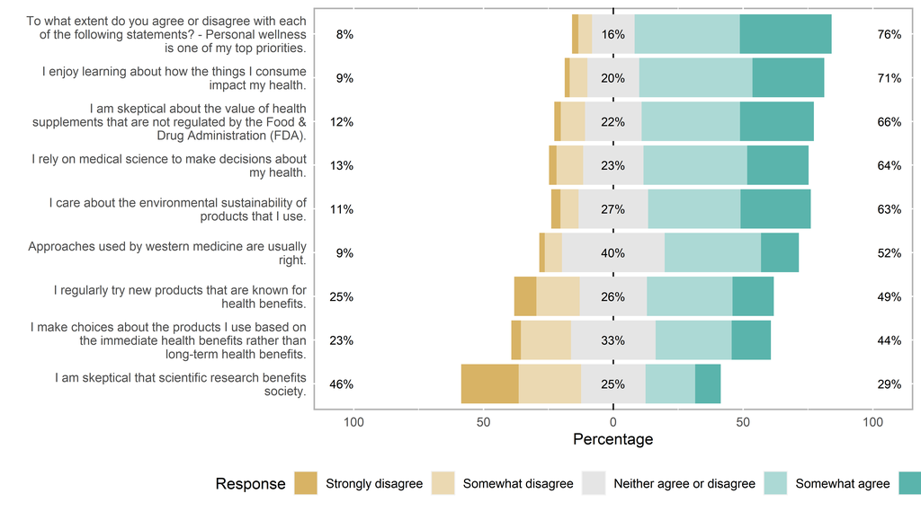

```r
plotLikertSorted(survey_philosophy)
```

### Attitude

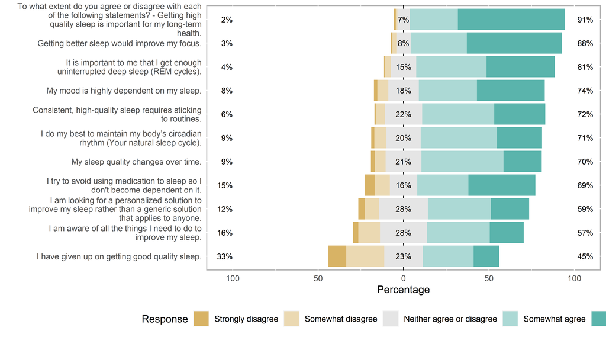

```r
plotLikertSorted(survey_attitude)  # only a wrapper to minimally improve plots
```

### Behavior

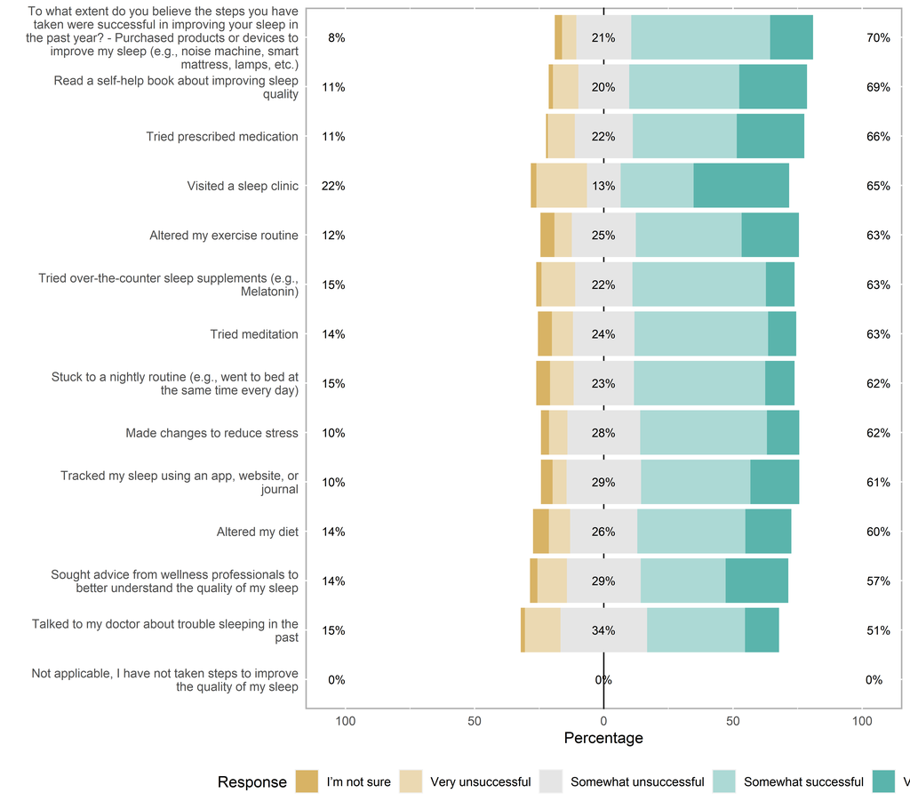

```r
plotLikertSorted(survey_behavior_a)
```

## Experiment data

Despite survey targeting those with a problem that product aims to help with, there is a skew in response (rating), showing that many are sceptical regardless of the feature mix. In addition, variability in ratings between different feature sets from each respondent, show that many are not even changing their answer, which isn’t helpful for modeling the responses.

Prevalence in ratings (answer from respondents)

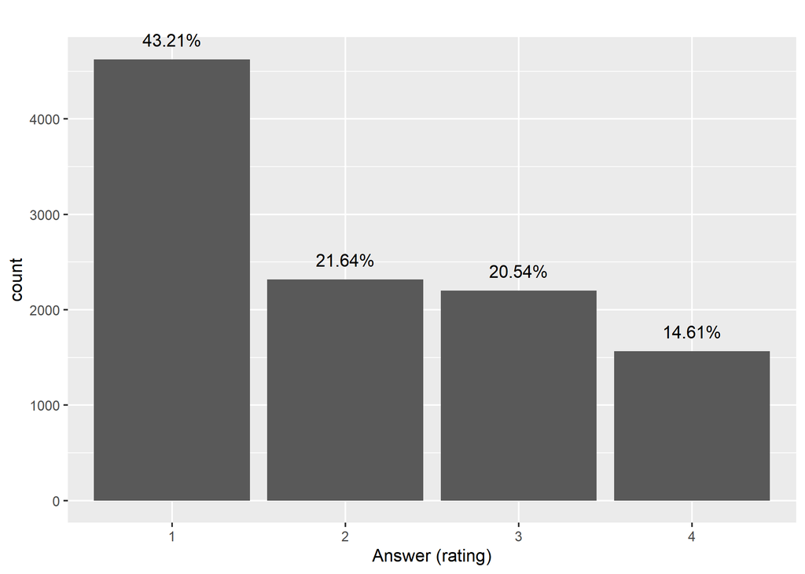

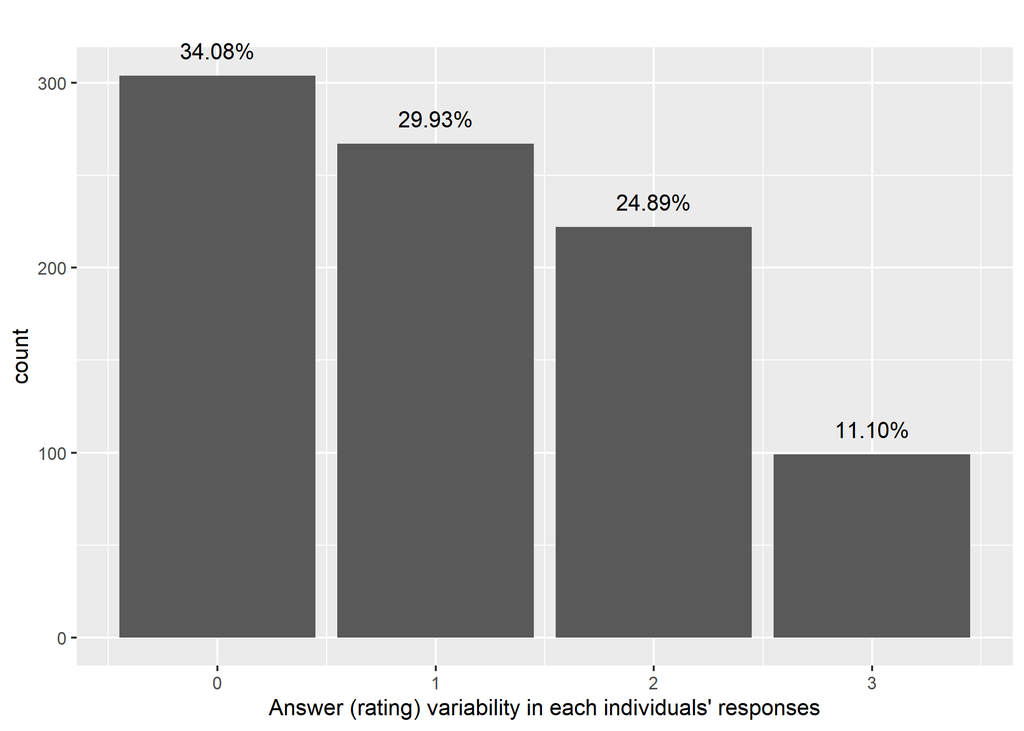

```r
ggplot(experiment_data[,"answer"], aes(x = answer)) + geom_bar() +
 geom_text(stat="count", vjust = -1,
           aes(label = sprintf("%1.2f%%", 100*(..count..)/sum(..count..)))) +
 labs(x = "Answer (rating)", title = '') + coord_cartesian(clip = "off")

ind_ans_rng <- experiment_data %>% group_by(response_id) %>%
                summarise_all(~diff(range(as.integer(.)))) %>%
                transmute(response_id = response_id, ind_answer_range = answer)

ggplot(ind_ans_rng[,"ind_answer_range"], aes(x = ind_answer_range)) + geom_bar() +
 geom_text(stat="count", vjust = -1,
           aes(label = sprintf("%1.2f%%", 100*(..count..)/sum(..count..)))) +
 labs(x = "Answer (rating) variability in each individuals' responses", title = '') +
 coord_cartesian(clip = "off")
```

## Index function

The `calcIdx()` function calculates the index of a level included in this variable in contrast to groups provided by levels of another variable. See `?calcIdx` for more info.

It can be used to find more divisive and therefore potentially more significant factors influencing the response.

```
# A tibble: 12 x 3
   hours             s_problem                                               idx
   <fct>             <fct>                                                 <dbl>
 1 Less than 4       Every night                                           259.
 2 Less than 4       Most nights (Four or more nights during a typical we~  68.6
 3 Less than 4       Sometimes (Two or three nights during a typical week)  13.0
 4 4-5 hours         Every night                                           112.
 5 4-5 hours         Most nights (Four or more nights during a typical we~ 131.
 6 4-5 hours         Sometimes (Two or three nights during a typical week)  63.8
 7 6-8 hours         Every night                                            54.9
 8 6-8 hours         Most nights (Four or more nights during a typical we~  78.4
 9 6-8 hours         Sometimes (Two or three nights during a typical week) 152.
10 More than 8 hours Every night                                           103.
11 More than 8 hours Most nights (Four or more nights during a typical we~  89.5
12 More than 8 hours Sometimes (Two or three nights during a typical week) 107.
```

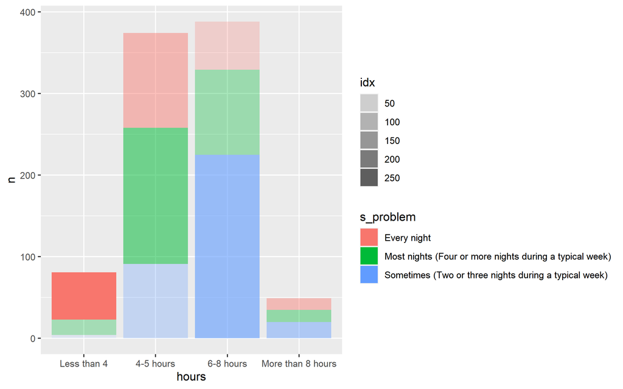

```r
calcIdx(grpVar = "hours", idxVar = "s_problem", dataset = survey_data) %T>%   # omits NAs by default
print() %>%
plotIdxPair(dtset = survey_data)
```

```r
calcIdx(grpVar = "price", idxVar = "answer", dataset = experiment_data) %>%
 arrange(idx) %>% knitr::kable()  # lower price is a favorable feature
```

| price | answer | idx |
| --- | --- | --- |
| $40/month | 3 | 79.16228 |
| $20/month | 1 | 85.33863 |
| $30/month | 4 | 87.59078 |
| $40/month | 4 | 90.33838 |
| $20/month | 2 | 93.34657 |
| $30/month | 3 | 99.04739 |
| $40/month | 2 | 102.06229 |
| $30/month | 1 | 102.37048 |
| $30/month | 2 | 104.55066 |
| $40/month | 1 | 112.14198 |
| $20/month | 3 | 122.03447 |
| $20/month | 4 | 122.22787 |

Below function call loops over all variables and calculates indices based on each pair. This is more useful for finding relationships between different explanatory variables (e.g. `mdl_data`), as in below example we are really only interested in combinations of profiles with answer variable.

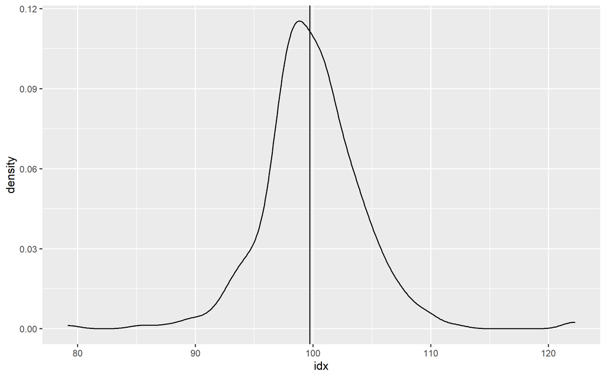

```r
# combined larger dataset, which can be used in modeling or a longer loop than below
mdl_data <- left_join(experiment_data, survey_data, by = "response_id")

expIdxsList <- calcIdxsAll(experiment_data[,-(1:2)]) # omit response_id & task
# may take > 5 mins on a larger combined dataset (e.g. mdl_data)

expIdxsTbl <- idxList2tbl(expIdxsList)  # convert list to tibble

expIdxsTbl <- expIdxsTbl %>%  # more readable labels for plot
                tidyr::unite(grp, c('grpVar', 'grpVal'), sep = ' : ') %>%
                tidyr::unite(lvl, c('lvlVar', 'lvlVal'), sep = ' : ')

ggplot(expIdxsTbl) + geom_density(aes(x = idx)) +
 geom_vline(xintercept = median(expIdxsTbl$idx, na.rm = T))
```

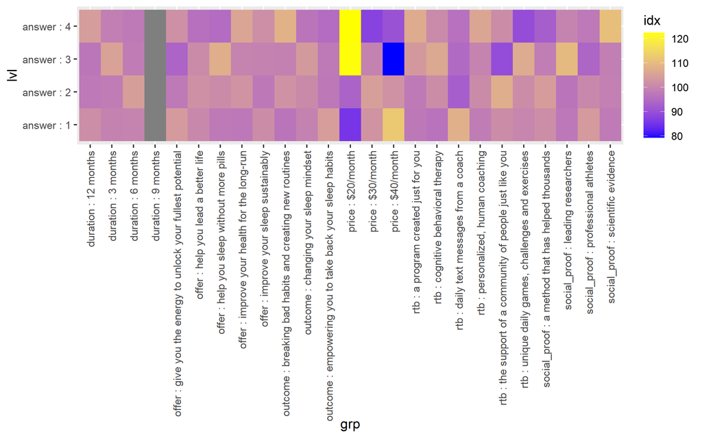

```r
ggplot(expIdxsTbl[grep('^answer', expIdxsTbl$lvl),], aes(grp, lvl, fill = idx)) +
 geom_tile() + scale_fill_gradient(low = "blue",  high = "yellow") +
 guides(x = guide_axis(angle = 90))
```

```r
# again shows that cheaper options are preferred, maybe also outcome2 & socialproof4

kable(expIdxsList$outcome$answer)  # particular sub-tables can be easily accessed
```

| outcome | answer | idx |
| --- | --- | --- |
| changing your sleep mindset | 1 | 99.09596 |
| changing your sleep mindset | 2 | 100.61239 |
| changing your sleep mindset | 3 | 103.53579 |
| changing your sleep mindset | 4 | 96.79520 |
| breaking bad habits and creating new routines | 1 | 96.76300 |
| breaking bad habits and creating new routines | 2 | 102.07094 |
| breaking bad habits and creating new routines | 3 | 98.88517 |
| breaking bad habits and creating new routines | 4 | 108.07312 |
| empowering you to take back your sleep habits | 1 | 104.17646 |
| empowering you to take back your sleep habits | 2 | 97.29337 |
| empowering you to take back your sleep habits | 3 | 97.51839 |
| empowering you to take back your sleep habits | 4 | 95.14674 |

This is not very good way to visualize the potential relationships, however it can be more useful on different data. A preference for lower price is confirmed but it’s harder to see positive impact of outcome2 “breaking bad habits and creating new routines.” Other groupings were also considered but weren’t too informative either.

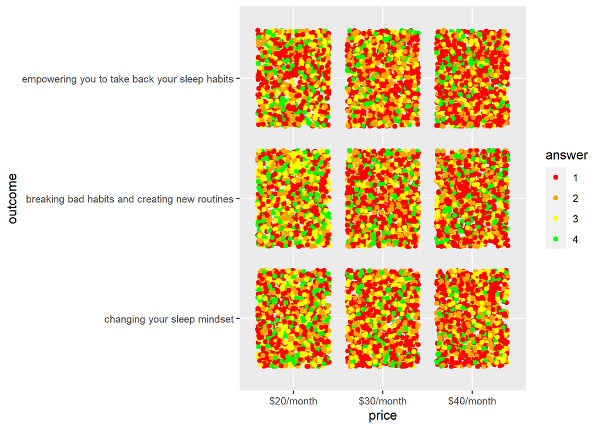

```r
ggplot(mdl_data, aes(x = price, y = outcome)) +
 geom_point(aes(color = answer), position = position_jitter()) +
 scale_color_manual(values = c("red",  "orange", "yellow", "green"))
```

Here we show how intensities of respondents and each individual response are obtained (calculation may take more than 10 minutes), so it is disabled by default and dataset comes pre-loaded. This can be used for grouping respondents, see section *To-do/More regressions incl. nested or conditional logit models* below on how this can be useful.

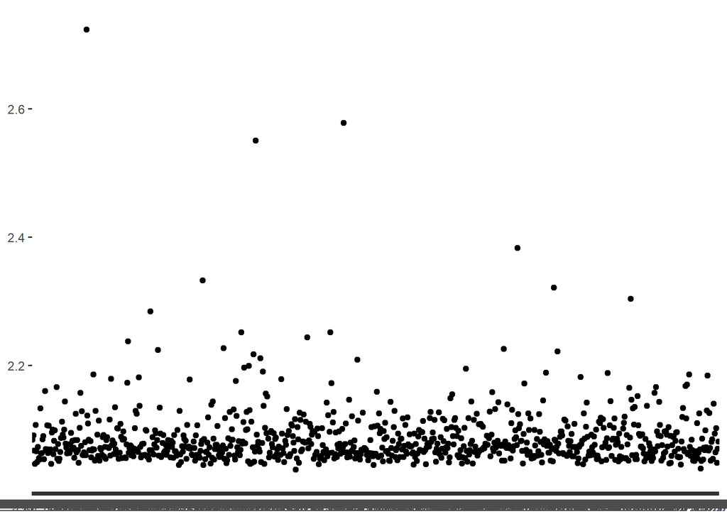

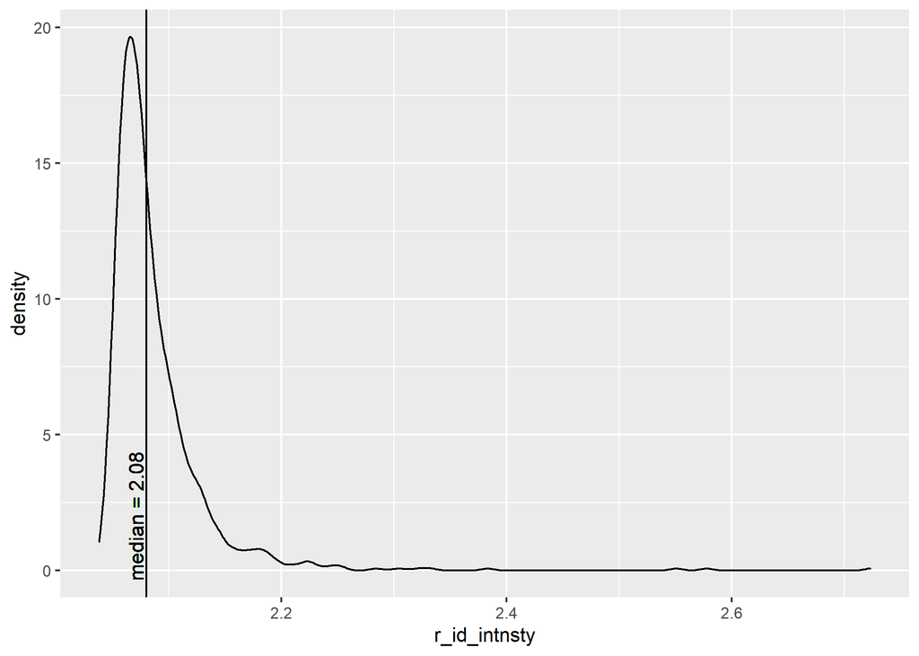

```r
surveyIdxsTbl <- survey_data %>% select(-response_id, -weights) %>%
  calcIdxsAll() %>% idxList2tbl()  # takes > 5 mins, functions should be made more efficient using dplyr instead of loops

# highlights how intense/radical are respondent's answers on average
survey_data[,'r_id_intnsty'] <- survey_data %>% dplyr::select(-weights) %>%
  rateResponses(surveyIdxsTbl, onlyIntensities = TRUE) %>% select(last_col())

# multiplies each response by its average index with relations to other responses
survey_data_all_intnsts <- survey_data %>% dplyr::select(-weights, -r_id_intnsty) %>%
  rateResponses(surveyIdxsTbl)  # may take up to ten minutes

ggplot(survey_data[,c('response_id', 'r_id_intnsty')], aes(y = r_id_intnsty, x = response_id)) +
 geom_point() + theme(axis.title = element_blank())

r_id_intnsty.med <- round(median(survey_data$r_id_intnsty, na.rm = T), 2)
ggplot(survey_data[,'r_id_intnsty']) + geom_density(aes(x = r_id_intnsty)) +
 geom_vline(xintercept = r_id_intnsty.med) + geom_text(aes(x = r_id_intnsty.med,
   label = paste("median =", r_id_intnsty.med)), y = 2, angle = 90, vjust = -0.2)

# split questions by approximate index scale (for comparability within groups)
svey_intnsts <- melt(survey_data_all_intnsts) %>% arrange(value)

svey_intnsts$variable <- as.character(svey_intnsts$variable)
svey_intnsts$category <- "demographics"
svey_intnsts$category[grep("_a_", svey_intnsts$variable)] <- "behavior_ans"
svey_intnsts$category[grep("m1_philos|m2_attit", svey_intnsts$variable)] <- "psychology"
svey_intnsts$category[grep("source|behavior_[1-9]|m2_aware", svey_intnsts$variable)] <-
 "source_awareness_behavior_Q"
svey_intnsts$category %<>% as_factor()
```

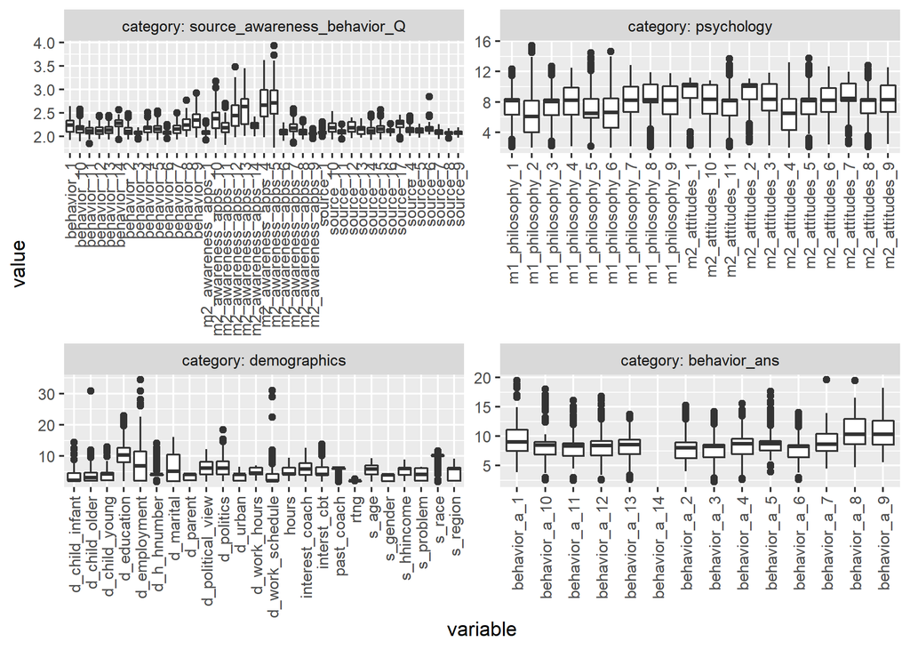

```r
# we can see more divisive groups/indices such m2_awareness_4 or 5 and d_employment
ggplot(svey_intnsts, aes(y = value, x = variable)) + geom_boxplot() +
  facet_wrap(facets = ~category, scale = "free", dir = 'v', labeller = label_both) +
  guides(x =  guide_axis(angle = 90))
```

# Modeling

Several approaches are tried here, however the provided dataset is more suitable for conjoint analysis, although it is not the first one listed here.

## Preparing variables

In the provided dataset `price` (per month) and `duration` (months) are related, and it may be beneficial to consider their combined effect. Both affect the overall (total) cost. Reminder: in Section 1 levels for price were reordered, and a missing one (9 months) for duration was added (to make levels equally spaced).

Unlike other features, `price` and `duration` are now ordered and equally spaced, so they can also be used as nominal not categorical variables in modeling. Same for `totalCost`.

```r
mdl_data %<>% mutate(totalCost = as.integer(duration) * 3 *
                                   (as.integer(price) + 1) * 10)
unique(mdl_data[,c('price', 'duration', 'totalCost')]) %>% arrange(totalCost)
```

| price | duration | totalCost |
| --- | --- | --- |
| $20/month | 3 months | 60 |
| $30/month | 3 months | 90 |
| $40/month | 3 months | 120 |
| $20/month | 6 months | 120 |
| $30/month | 6 months | 180 |
| $40/month | 6 months | 240 |
| $20/month | 12 months | 240 |
| $30/month | 12 months | 360 |
| $40/month | 12 months | 480 |

## Regression

“For estimating the utilities for each attribute level using ratings-based full profile tasks, linear regression may be appropriate. Bayesian estimators are also very popular.” (Wikipedia contributors 2021).

Survey data carries *weights*, which should probably be also included in the model. For the provided dataset they tend to improve fit. In case of more information (parameters) being available about complex survey design (sampling, clustering, stratification methods, etc), some dedicated packages such as `survey`(Lumley 2011) and `srvyr` can be considered to be used.

```r
#library(MASS)  # polr
ord_reg_naive <- MASS::polr(formula = answer ~ price + duration + rtb + offer + outcome + social_proof,
                      data = mdl_data, weights = mdl_data$weights, Hess = TRUE)  # method = 'probit' can also be tried

ord_reg_naive %>% summary() %T>% print() %>%
{round(pnorm(abs(coef(.)[, "t value"]), lower.tail = F) * 2, dig = 2)}  # p-values
```

```
Call:
MASS::polr(formula = answer ~ price + duration + rtb + offer +
    outcome + social_proof, data = mdl_data, weights = mdl_data$weights,
    Hess = TRUE)

Coefficients:
                                                               Value Std. Error
price$30/month                                            -0.3349057    0.04083
price$40/month                                            -0.5335246    0.04123
duration6 months                                          -0.0788675    0.04087
duration12 months                                         -0.0657797    0.04113
rtbdaily text messages from a coach                       -0.1624980    0.05817
rtba program created just for you                          0.0094421    0.05682
rtbthe support of a community of people just like you     -0.1378067    0.05756
rtbunique daily games, challenges and exercises           -0.0592987    0.05670
rtbpersonalized, human coaching                           -0.0014032    0.05665
offerimprove your sleep sustainably                       -0.0209257    0.05368
offergive you the energy to unlock your fullest potential -0.0236726    0.05249
offerhelp you sleep without more pills                     0.0326437    0.05307
offerimprove your health for the long-run                  0.0942322    0.05253
outcomebreaking bad habits and creating new routines       0.0288416    0.04077
outcomeempowering you to take back your sleep habits      -0.0771908    0.04119
social_proofa method that has helped thousands            -0.1136216    0.04762
social_proofprofessional athletes                         -0.1197936    0.04778
social_proofscientific evidence                           -0.0006425    0.04722
                                                            t value
price$30/month                                             -8.20194
price$40/month                                            -12.94049
duration6 months                                           -1.92968
duration12 months                                          -1.59914
rtbdaily text messages from a coach                        -2.79339
rtba program created just for you                           0.16619
rtbthe support of a community of people just like you      -2.39404
rtbunique daily games, challenges and exercises            -1.04592
rtbpersonalized, human coaching                            -0.02477
offerimprove your sleep sustainably                        -0.38982
offergive you the energy to unlock your fullest potential  -0.45099
offerhelp you sleep without more pills                      0.61506
offerimprove your health for the long-run                   1.79393
outcomebreaking bad habits and creating new routines        0.70737
outcomeempowering you to take back your sleep habits       -1.87390
social_proofa method that has helped thousands             -2.38625
social_proofprofessional athletes                          -2.50714
social_proofscientific evidence                            -0.01361

Intercepts:
    Value    Std. Error t value
1|2  -0.7536   0.0736   -10.2434
2|3   0.2140   0.0731     2.9270
3|4   1.4450   0.0749    19.2870

Residual Deviance: 30917.15
AIC: 30959.15
```

```
                                           price$30/month
                                                     0.00
                                           price$40/month
                                                     0.00
                                         duration6 months
                                                     0.05
                                        duration12 months
                                                     0.11
                      rtbdaily text messages from a coach
                                                     0.01
                        rtba program created just for you
                                                     0.87
    rtbthe support of a community of people just like you
                                                     0.02
          rtbunique daily games, challenges and exercises
                                                     0.30
                          rtbpersonalized, human coaching
                                                     0.98
                      offerimprove your sleep sustainably
                                                     0.70
offergive you the energy to unlock your fullest potential
                                                     0.65
                   offerhelp you sleep without more pills
                                                     0.54
                offerimprove your health for the long-run
                                                     0.07
     outcomebreaking bad habits and creating new routines
                                                     0.48
     outcomeempowering you to take back your sleep habits
                                                     0.06
           social_proofa method that has helped thousands
                                                     0.02
                        social_proofprofessional athletes
                                                     0.01
                          social_proofscientific evidence
                                                     0.99
                                                      1|2
                                                     0.00
                                                      2|3
                                                     0.00
                                                      3|4
                                                     0.00
```

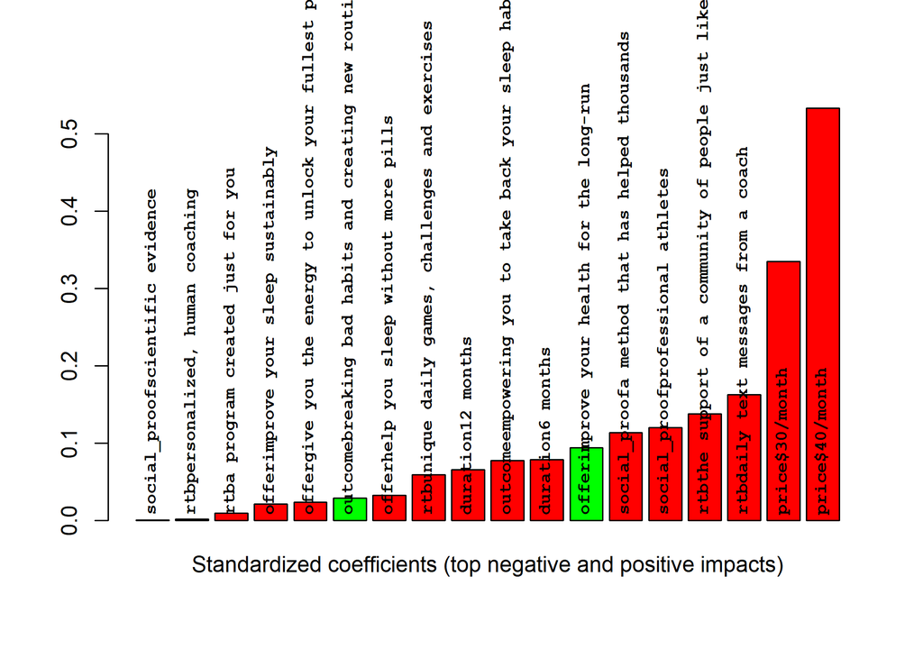

```r
impacts <- ord_reg_naive$coefficients  # ordinal regression already produces standardized coeffs (betas)
# att_infl['totalCost'] <- att_infl['totalCost'] *  # except, for $ totalCost (if included)
#                           sd(as.integer(mdl_data$totalCost)) /  # as it's nominal
#                           sd(as.integer(mdl_data$answer))

bp <- barplot(sort(abs(impacts)), names.arg = FALSE,
              col = c('red', 'green')[1 + (abs(impacts) < impacts[order(abs(impacts))])])
title(sub = "Standardized coefficients (top negative and positive impacts)", line = 1)
axis(side = 1, hadj = -0.06, at = bp, las = 2, tick = F, cex.axis = 0.8, padj = 0.25, font = 11,
     labels = format(names(sort(abs(impacts))), width = max(nchar(names(impacts)))))
```

The issue with this approach is that most of the variables are obviously insignificant, but it does provide some idea, e.g. again showing positive impact of lowest price.

## Dimensionality reduction

When dealing with many variables it is often the case that several variables are related and represent a common, underlying factor. To find such underlying factors, we can use a factor analysis. Principal component analysis is also used when several questions or variables reflect a common factor and they should be combined into a single variable, e.g. during the statistical analysis of the data. Thus, principal component analysis can be used to collapse different variables (or questions) into one (Schweinberger 2020).

Given that variance doesn’t change much within groups Linear Discriminant Analysis (LDA) was considered here. Also, given that we are dealing with more than two categorical variables, Multiple Correspondence Analysis (MCA) was tried. However, these attempts do not appear successful at first glance. For `MASS::lda`, even if they were, coefficients are standardized (the value for each discriminant function is scaled so that their mean value is zero and its variance is one), but `predict` can be used to both test the performance (e.g. by splitting dataset in two parts: fitting and out-of-sample) and more practically calculate the impact, if interpretation is otherwise difficult. Some guidance is available [here.](https://rstudio-pubs-static.s3.amazonaws.com/35817_2552e05f1d4e4db8ba87b334101a43da.html)

```r
#library(psych)  # dimensionality reduction:
#library(GPArotation)
library(FactoMineR)
library(factoextra)

library(car)
#library(Hmisc)
library(RVAideMemoire)

library(zoo)
#library(survival)

#library(mvtnorm) ## ? lr4, boot, coxme, knitr, leaps, lmtest, Matrix,
        #MatrixModels, rgl (>= 0.93.960), sandwich, SparseM, survival,
        #survey, scales
#library(tibble)
#library(Formula)
#library(conjoint)

experiment_data %>% dplyr::select(-response_id) %>% group_by(answer) %>%
                    summarise_all(~sd(as.integer(.)))
```

| answer | task | duration | offer | outcome | price | rtb | social_proof |
| --- | --- | --- | --- | --- | --- | --- | --- |
| 1 | 3.435795 | 1.242209 | 1.405999 | 0.8235925 | 0.8066596 | 1.706528 | 1.104469 |
| 2 | 3.479172 | 1.225458 | 1.424698 | 0.8127784 | 0.8069638 | 1.716015 | 1.106108 |
| 3 | 3.480766 | 1.238559 | 1.419491 | 0.8190382 | 0.8069925 | 1.734217 | 1.132988 |
| 4 | 3.420444 | 1.250328 | 1.415813 | 0.8005887 | 0.8357157 | 1.721457 | 1.137074 |

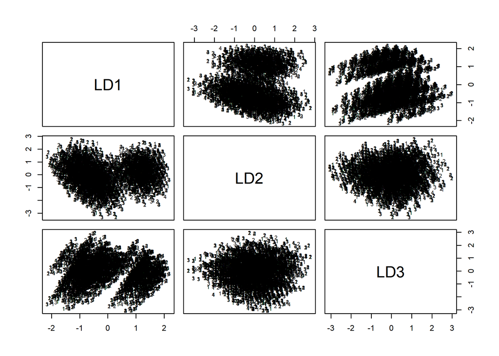

```r
# variance doesn't change much within groups, can try LDA

# due to missing duration = 9 months (3, 6, 12 present):
LDA_answer <- MASS::lda(answer ~ ., mutate(experiment_data[,-(1:2)],
                                           duration = as.integer(duration)))
# suggests bad impact of higher prices, rtb2 and rtb4, sprf3,
plot(LDA_answer)  # looks rather messy
```

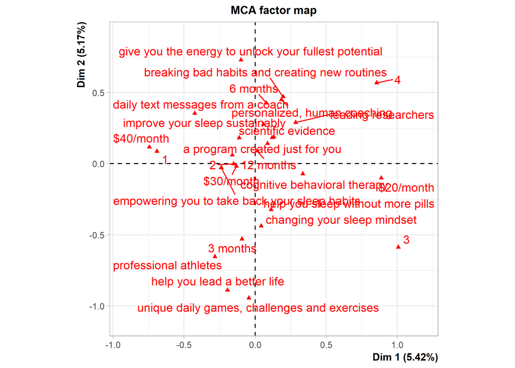

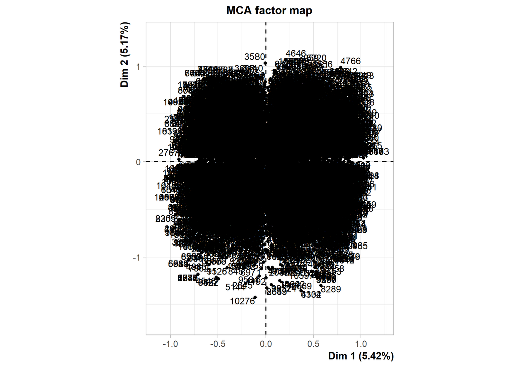

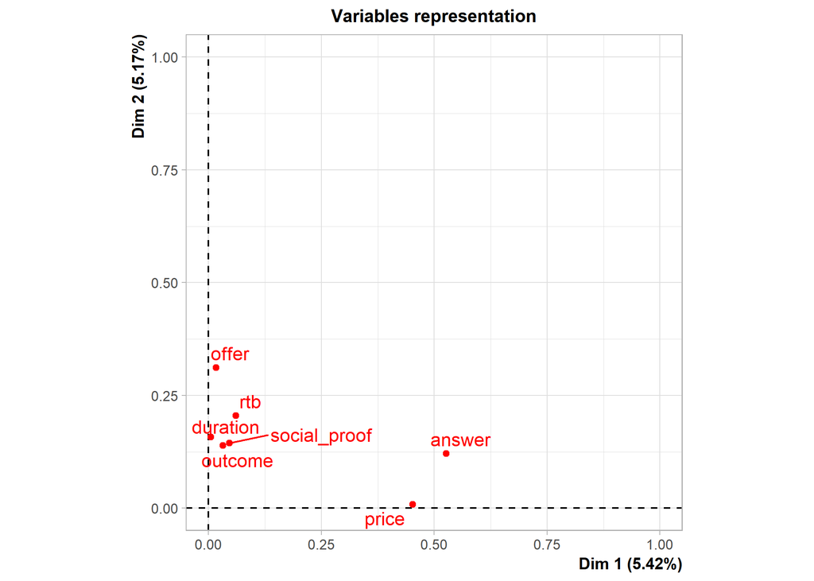

```r
MCA_ans <- MCA(experiment_data[,-(1:2)], ncp = 5, graph = TRUE)
```

```r
summary(MCA_ans)  # shows that price should be included in a model separately?
```

```
Call:
MCA(X = experiment_data[, -(1:2)], ncp = 5, graph = TRUE)


Eigenvalues
                       Dim.1   Dim.2   Dim.3   Dim.4   Dim.5   Dim.6   Dim.7
Variance               0.163   0.155   0.154   0.149   0.148   0.148   0.146
% of var.              5.424   5.173   5.140   4.975   4.940   4.924   4.853
Cumulative % of var.   5.424  10.598  15.738  20.713  25.653  30.577  35.430
                       Dim.8   Dim.9  Dim.10  Dim.11  Dim.12  Dim.13  Dim.14
Variance               0.145   0.145   0.143   0.143   0.142   0.141   0.139
% of var.              4.846   4.834   4.779   4.761   4.721   4.698   4.632
Cumulative % of var.  40.276  45.110  49.889  54.650  59.372  64.069  68.701
                      Dim.15  Dim.16  Dim.17  Dim.18  Dim.19  Dim.20  Dim.21
Variance               0.138   0.138   0.137   0.137   0.134   0.132   0.123
% of var.              4.612   4.593   4.571   4.558   4.467   4.385   4.114
Cumulative % of var.  73.313  77.906  82.477  87.035  91.502  95.886 100.000

Individuals (the 10 first)
                                                        Dim.1    ctr   cos2
1                                                    |  0.442  0.011  0.063 |
2                                                    | -0.178  0.002  0.009 |
3                                                    |  0.267  0.004  0.023 |
4                                                    | -0.521  0.016  0.098 |
5                                                    |  0.035  0.000  0.000 |
6                                                    |  0.816  0.038  0.199 |
7                                                    |  0.292  0.005  0.027 |
8                                                    |  0.448  0.012  0.063 |
9                                                    |  0.022  0.000  0.000 |
10                                                   |  0.202  0.002  0.013 |
                                                      Dim.2    ctr   cos2
1                                                    -0.812  0.040  0.213 |
2                                                     0.117  0.001  0.004 |
3                                                     0.174  0.002  0.010 |
4                                                    -0.032  0.000  0.000 |
5                                                     0.031  0.000  0.000 |
6                                                     0.678  0.028  0.137 |
7                                                     0.076  0.000  0.002 |
8                                                     0.212  0.003  0.014 |
9                                                     0.440  0.012  0.057 |
```

[output cut: 53 more lines]

```
give you the energy to unlock your fullest potential   0.505   0.007   8.578 |
help you sleep without more pills                      2.136   0.029 -17.516 |
improve your health for the long-run                   2.626   0.035  19.479 |
changing your sleep mindset                            2.007   0.033  18.699 |
breaking bad habits and creating new routines          0.092   0.001  -3.992 |

Categorical variables (eta2)
                                                       Dim.1 Dim.2 Dim.3
duration                                             | 0.005 0.158 0.108 |
offer                                                | 0.016 0.312 0.104 |
outcome                                              | 0.032 0.139 0.036 |
price                                                | 0.452 0.008 0.164 |
rtb                                                  | 0.061 0.205 0.241 |
social_proof                                         | 0.047 0.144 0.321 |
answer                                               | 0.526 0.121 0.106 |
```

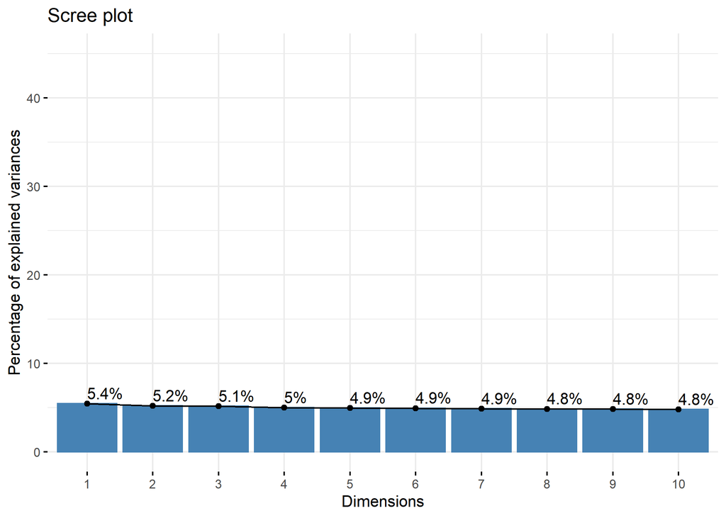

```r
fviz_screeplot(MCA_ans, addlabels = TRUE, ylim = c(0, 45))  # no useful results
```

## Conjoint analysis

Implementation was found in `conjoint`(Bartłomowicz and Bąk 2019), `radiant`(KU Leuven Marketing department 2021), and `choicetools`(Chris Chapman 2021) packages. Only the use of the first two is shown here. Also, only respondents who rated the profile at least once other than “1,” were selected. This is due to, when fitting regressions on full sample, having specifications (estimates), which lead to models always predicting the same (e.g. “1”) answer. Conjoint analysis also uses linear regression, hence sample adjustment is performed already here.

The utilities computed below show how each level relatively influences the respondent’s rating of product’s profile, i.e. likeliness to download.

```r
# filter out respondents that always rate everything "1"
ans.resp.stats <-
 mdl_data %>% group_by(response_id) %>%
 summarise(stvty = diff(range(as.integer(answer))), maxAns = max(as.integer(answer)))

mdl_data.sens <- mdl_data %>%  # stvty can also be used to slice sample; only maxAns is used below
 filter(response_id %in% ans.resp.stats[ans.resp.stats$maxAns > 1,][["response_id"]])

#experim_dt.sens <- experiment_data %>%  # for runConjoint, which requires tibble
# filter(response_id %in% ans.resp.stats[ans.resp.stats$maxAns > 1,][["response_id"]])

nrow(mdl_data.sens) / nrow(mdl_data)  # cuts sample by more than 1/4
```

```
[1] 0.7320628
```

```r
summary(mdl_data.sens$answer)  # now almost symmetric sample
```

```
   1    2    3    4
1757 2316 2199 1564
```

```r
# conjoint::Conjoint is commented out as it takes longer to run and produces many plots
# it produces slightly different results than radiant::conjoint, reasons for which needs to be learnt
#sel.smpl.cnjnt <- invisible(
#runConjoint(experim_dt.sens[spl_indxs,], yCol = "answer",
#           fctCols = c("price", "duration", "offer", "outcome", "social_proof", "rtb")))

# alternatively can use radiant package:
sel.smpl.cnjnt.rad <-
  conjoint(mdl_data.sens, rvar = "answer", evar = c(
                               "price", "duration", "offer", "outcome", "social_proof", "rtb"))
sel.smpl.cnjnt.rad$model_list$full$tab$PW %>% as_tibble(rownames = NULL)
```

| Attributes | Levels | PW |
| --- | --- | --- |
| price | $20/month | 0.000 |
| price | $30/month | -0.298 |
| price | $40/month | -0.415 |
| duration | 3 months | 0.000 |
| duration | 6 months | -0.001 |
| duration | 9 months | 0.000 |
| duration | 12 months | 0.039 |
| offer | help you lead a better life | 0.000 |
| offer | improve your sleep sustainably | 0.062 |
| offer | give you the energy to unlock your fullest potential | 0.051 |

[output cut: 16 more lines]

Results of `caImportance` function call show each attribute’s relative impact (sums to 100%).

```r
# This function has side effects (sets global options). Will change output from radiant::conjoint
savedTbl <- sel.smpl.cnjnt.rad$model_list$full$coeff[,
                    c('label', 'coefficient', 'p.value')]

conjoint::caImportance(y = experiment_data[,'answer'], x = unique(experiment_data[,
            c("price", "duration", "offer", "outcome", "social_proof", "rtb")]))
```

```
[1] 15.37  4.51 12.33 12.36 18.67 36.76
```

## Enhanced regressions

Coefficients’ significance provided by conjoint analysis inspired better model specifications that were fitted before. More precise estimation of most material (scale of impact) and significant (certainty) influences can be obtained from regression coefficients (betas), compared to conjoint analysis above.

```r
savedTbl # otherwise significance replaced with NAs
```

| label | coefficient | p.value |
| --- | --- | --- |
| (Intercept) | 2.6870519516 | NA |
| price\|$30/month | -0.2981026599 | NA |
| price\|$40/month | -0.4149460922 | NA |
| duration\|6 months | -0.0007343982 | NA |
| duration\|12 months | 0.0385718145 | NA |
| offer\|improve your sleep sustainably | 0.0616333676 | NA |
| offer\|give you the energy to unlock your fullest potential | 0.0507316837 | NA |
| offer\|help you sleep without more pills | 0.0676321787 | NA |
| offer\|improve your health for the long-run | 0.1150291555 | NA |
| outcome\|breaking bad habits and creating new routines | 0.0461750572 | NA |

[output cut: 9 more lines]

New categorical (dummy) variables are prepared, alternatively e.g. `I(rtb == 3)` can be used in formulas. Sample is split into fitting (90%) and performance testing (10%) parts.

```r
mdl_data.sens %<>%
 cbind(priceUSD = (as.integer(mdl_data.sens$price) + 1) * 10,
       price3   = ifelse(as.integer(mdl_data.sens$price) == 3L, 1, 0),
       durMns   = as.integer(mdl_data.sens$duration) * 3,
       dur6M   = ifelse(as.integer(mdl_data.sens$duration) == 2L, 1, 0),
       sprf1    = ifelse(as.integer(mdl_data.sens$social_proof) == 1L, 1, 0),
       sprf4    = ifelse(as.integer(mdl_data.sens$social_proof) == 4L, 1, 0),
       rtbIs2   = ifelse(as.integer(mdl_data.sens$rtb) == 2L, 1, 0),
       rtbIs4   = ifelse(as.integer(mdl_data.sens$rtb) == 4L, 1, 0),
       rtbIs5   = ifelse(as.integer(mdl_data.sens$rtb) == 5L, 1, 0),
       offer1   = ifelse(as.integer(mdl_data.sens$offer) == 1L, 1, 0),
       offer5   = ifelse(as.integer(mdl_data.sens$offer) == 5L, 1, 0),
       outIs2   = ifelse(as.integer(mdl_data.sens$outcome) == 2L, 1, 0),
       outIs3   = ifelse(as.integer(mdl_data.sens$outcome) == 3L, 1, 0))

# split 10% of sample into out-of-sample (used for prediction performance measurement, not fitting)
spl_indxs <- sample(1:nrow(mdl_data.sens), 0.9 * nrow(mdl_data.sens), replace = FALSE)
fit_sample <- mdl_data.sens[spl_indxs,]
prd_sample <- mdl_data.sens[-spl_indxs,]



# diverse models (in terms of regressors, test results) are selected below,
# it is more interesting to check in oos performance than select purely on fit
# (e.g. lowest IC)
library(ordinal)
library(car)
m1 <-
clm(formula = answer ~ sprf1 + rtbIs2 + offer1 + I(totalCost < 240),
     data = fit_sample, weights = fit_sample$weights)
m1 %>% summary()  # rtbIs4, outIs3, dur3 marginal
```

```
formula: answer ~ sprf1 + rtbIs2 + offer1 + I(totalCost < 240)
data:    fit_sample

 link  threshold nobs     logLik    AIC      niter max.grad cond.H
 logit flexible  7998.964 -10901.79 21817.58 4(0)  6.60e-09 1.7e+01

Coefficients:
                    Estimate Std. Error z value Pr(>|z|)
sprf1                0.08457    0.04637   1.824  0.06815 .
rtbIs2              -0.06329    0.05614  -1.127  0.25956
offer1              -0.11668    0.04990  -2.338  0.01938 *
I(totalCost < 240)1 -0.06261    0.02032  -3.082  0.00206 **
---
Signif. codes:  0 '***' 0.001 '**' 0.01 '*' 0.05 '.' 0.1 ' ' 1

Threshold coefficients:
    Estimate Std. Error z value
1|2 -1.24996    0.03232 -38.675
2|3  0.15498    0.02880   5.381
3|4  1.51746    0.03439  44.119
```

```r
m1 %>% Anova(type = "II")  # priceUSD marginal
```

|  | Df | Chisq | Pr(>Chisq) |
| --- | --- | --- | --- |
| sprf1 | 1 | 1495.724753 | 0.000000e+00 |
| rtbIs2 | 1 | 28.955805 | 7.404858e-08 |
| offer1 | 1 | 1946.452518 | 0.000000e+00 |
| I(totalCost < 240) | 1 | 3.326961 | 6.815270e-02 |

```r
m2 <-
clm(formula = answer ~ sprf4 + rtbIs5 + offer1 + price3 + dur6M,
     data = fit_sample, weights = fit_sample$weights)
m2 %>% summary()  # sprf4, rtbIs5 marginal
```

```
formula: answer ~ sprf4 + rtbIs5 + offer1 + price3 + dur6M
data:    fit_sample

 link  threshold nobs     logLik    AIC      niter max.grad cond.H
 logit flexible  7998.964 -10832.88 21681.77 4(0)  3.26e-08 2.2e+01

Coefficients:
       Estimate Std. Error z value Pr(>|z|)
sprf4   0.03861    0.04593   0.841  0.40051
rtbIs5 -0.12420    0.05401  -2.300  0.02147 *
offer1 -0.13874    0.04999  -2.775  0.00552 **
price3 -0.52208    0.04328 -12.064  < 2e-16 ***
dur6M  -0.03643    0.04269  -0.853  0.39340
---
Signif. codes:  0 '***' 0.001 '**' 0.01 '*' 0.05 '.' 0.1 ' ' 1

Threshold coefficients:
    Estimate Std. Error z value
1|2 -1.48634    0.03962 -37.517
2|3 -0.06004    0.03529  -1.701
3|4  1.31509    0.03914  33.599
```

```r
m2 %>% Anova(type = "II")  # price3, dur3 marginal
```

|  | Df | Chisq | Pr(>Chisq) |
| --- | --- | --- | --- |
| sprf4 | 1 | 1407.525060 | 4.866543e-308 |
| rtbIs5 | 1 | 2.894262 | 8.889547e-02 |
| offer1 | 1 | 1128.871823 | 1.753203e-247 |
| price3 | 1 | 0.706785 | 4.005132e-01 |
| dur6M | 1 | 5.288286 | 2.146935e-02 |

```r
m3 <-
clm(formula = answer ~ sprf4 + rtbIs4 + offer5 + priceUSD + dur6M,
     data = fit_sample, weights = fit_sample$weights)
m3 %>% summary()  # outIs3 insignificant; sprf4 marginal
```

```
formula: answer ~ sprf4 + rtbIs4 + offer5 + priceUSD + dur6M
data:    fit_sample

 link  threshold nobs     logLik    AIC      niter max.grad cond.H
 logit flexible  7998.964 -10781.51 21579.02 4(0)  7.24e-08 4.7e+04

Coefficients:
          Estimate Std. Error z value Pr(>|z|)
sprf4     0.047320   0.045970   1.029  0.30331
rtbIs4   -0.159187   0.054978  -2.895  0.00379 **
offer5    0.142304   0.049764   2.860  0.00424 **
priceUSD -0.038796   0.002495 -15.552  < 2e-16 ***
dur6M    -0.037449   0.042723  -0.877  0.38073
---
Signif. codes:  0 '***' 0.001 '**' 0.01 '*' 0.05 '.' 0.1 ' ' 1

Threshold coefficients:
    Estimate Std. Error z value
1|2 -2.43073    0.08524 -28.517
2|3 -0.99035    0.08101 -12.226
3|4  0.39698    0.08104   4.899
```

```r
m3 %>% Anova(type = "II")  # outIs3 insignificant; priceUSD marginal
```

|  | Df | Chisq | Pr(>Chisq) |
| --- | --- | --- | --- |
| sprf4 | 1 | 813.202178 | 7.272759e-179 |
| rtbIs4 | 1 | 149.468774 | 2.265032e-34 |
| offer5 | 1 | 23.998169 | 9.642735e-07 |
| priceUSD | 1 | 1.059591 | 3.033085e-01 |
| dur6M | 1 | 8.383607 | 3.786203e-03 |

There quickly fitted models never project most negative/positive answer (1, 4), and are too conservative. They are only slightly better than just a median.

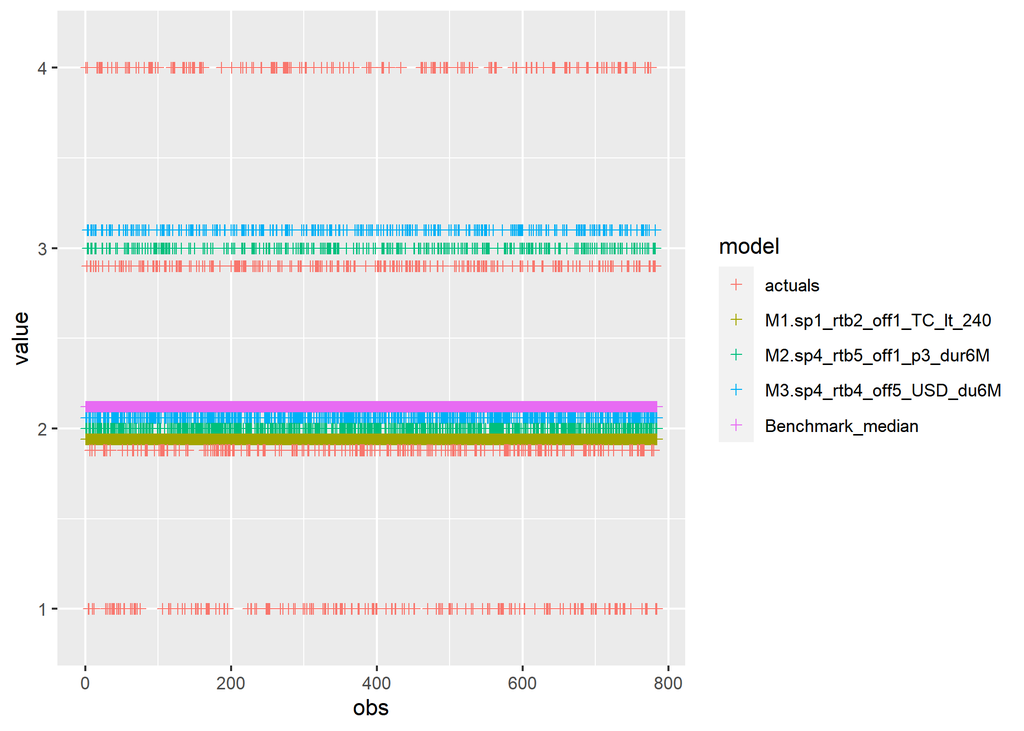

```r
m1.oos <- predict(m1, prd_sample[,-which(names(prd_sample) == 'answer')])$fit %>%
 apply(MARGIN = 1, FUN = function(i) which(i == max(i)))
m2.oos <- predict(m2, prd_sample[,-which(names(prd_sample) == 'answer')])$fit %>%
 apply(MARGIN = 1, FUN = function(i) which(i == max(i)))
m3.oos <- predict(m3, prd_sample[,-which(names(prd_sample) == 'answer')])$fit %>%
 apply(MARGIN = 1, FUN = function(i) which(i == max(i)))

m1.m2.m3.oos <- setNames(cbind.data.frame(1:nrow(prd_sample), as.integer(prd_sample$answer),
                                          m1.oos, m2.oos, m3.oos, median(as.integer(fit_sample$answer))),
                         c("obs", "actuals", "M1.sp1_rtb2_off1_TC_lt_240",
                           "M2.sp4_rtb5_off1_p3_dur6M",
                           "M3.sp4_rtb4_off5_USD_du6M", "Benchmark_median"))

ggplot(melt(m1.m2.m3.oos, id = 'obs', variable.name = 'model'),
       aes(x = obs, y = value, color = model)) + geom_point(shape = 3, position = position_dodgev(height=0.3))
```

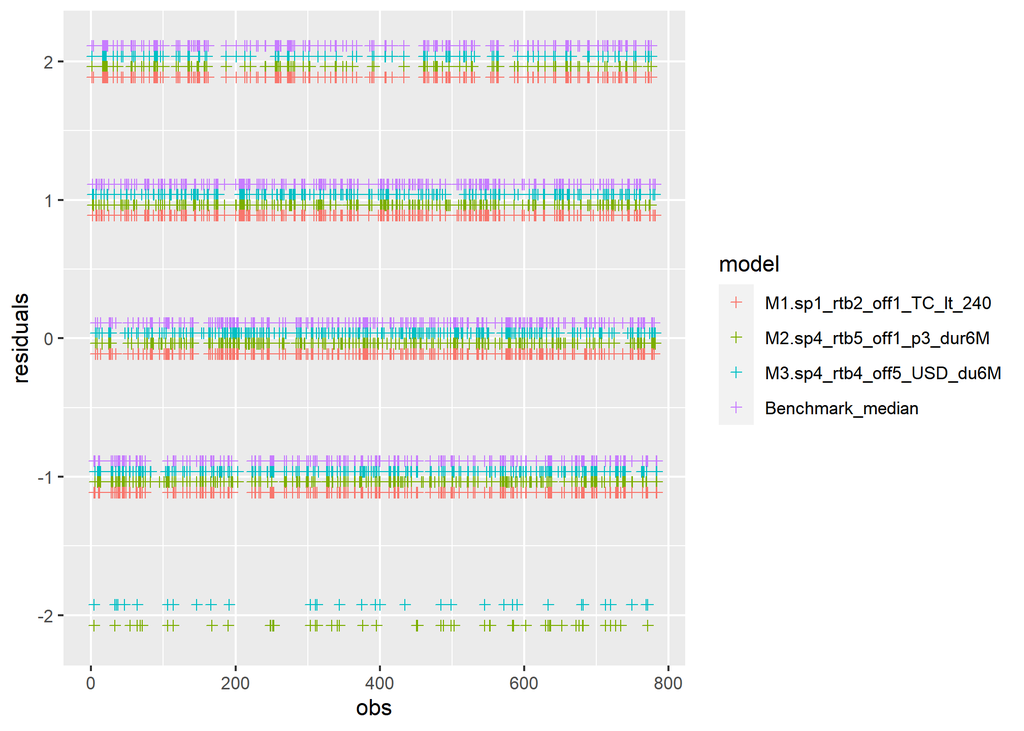

```r
m1.m2.m3.oos.rsd <- transmute(m1.m2.m3.oos, obs = obs,
                              M1.sp1_rtb2_off1_TC_lt_240 = actuals - M1.sp1_rtb2_off1_TC_lt_240,
                              M2.sp4_rtb5_off1_p3_dur6M  = actuals - M2.sp4_rtb5_off1_p3_dur6M,
                              M3.sp4_rtb4_off5_USD_du6M  = actuals - M3.sp4_rtb4_off5_USD_du6M,
                              Benchmark_median = actuals - Benchmark_median)

ggplot(melt(m1.m2.m3.oos.rsd, id = 'obs', variable.name = 'model', value.name = "residuals"),
       aes(x = obs, y = residuals, color = model)) +
 geom_point(shape = 3, position = position_dodgev(height=0.3))
```

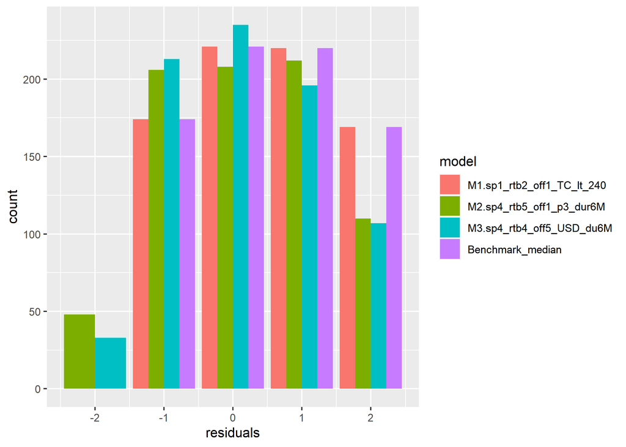

```r
ggplot(melt(m1.m2.m3.oos.rsd, id = 'obs', variable.name = 'model', value.name = "residuals"),
       aes(x = residuals, fill = model)) + geom_bar(position = "dodge")
```

```r
as.data.frame(lapply(m1.m2.m3.oos[,-(1:2)], function(mpred)
    c(RMSE = radiant.model:::RMSE(mpred, m1.m2.m3.oos[[2]]),
      MAE = radiant.model:::MAE(mpred, m1.m2.m3.oos[[2]]))))
```

|  | M1.sp1_rtb2_off1_TC_lt_240 | M2.sp4_rtb5_off1_p3_dur6M | M3.sp4_rtb4_off5_USD_du6M | Benchmark_median |
| --- | --- | --- | --- | --- |
| RMSE | 1.1682448 | 1.1572751 | 1.1117416 | 1.1682448 |
| MAE | 0.9336735 | 0.9362245 | 0.8788265 | 0.9336735 |

```r
exp(coefficients(m3))
```

```
       1|2        2|3        3|4      sprf4     rtbIs4     offer5   priceUSD
0.08797237 0.37144628 1.48733149 1.04845758 0.85283691 1.15292744 0.96194715
     dur6M
0.96324367
```

# To-do

## More regressions incl. nested or conditional logit models (*in progress*)

Also, random effects (partial pooling), respondents with certain traits are part of populations with such traits with some deviation (randomness). Therefore, multilevel frequentist models can make use of individual responses as well as aggregated into groups of individuals by certain unifying criteria (e.g., `survey_data` demographics). Rating can then be explained by both product’s profile and respondent’s profile.

Here’s a simple mixed effect model out of several fitted ones. It is inspired by above analysis (choice of variables) but offers an improvement on M1-M3 presented above (per lower value of AIC).

```r
me_cl2 <-
clmm(formula = answer ~ 1 + price + rtb + offer + social_proof + (1 | response_id), data = fit_sample, weights = fit_sample$weights)

me_cl2 %>% summary()
```

```
Cumulative Link Mixed Model fitted with the Laplace approximation

formula: answer ~ 1 + price + rtb + offer + social_proof + (1 | response_id)
data:    fit_sample

 link  threshold nobs     logLik   AIC      niter       max.grad cond.H
 logit flexible  7998.964 -8097.41 16230.82 2482(24726) 3.49e-03 6.3e+01

Random effects:
 Groups      Name        Variance Std.Dev.
 response_id (Intercept) 6.969    2.64
Number of groups:  response_id 653

Coefficients:
              Estimate Std. Error z value Pr(>|z|)
price1         0.78375    0.03573  21.934  < 2e-16 ***
price2        -0.12865    0.03413  -3.769 0.000164 ***
rtb1           0.05562    0.05225   1.064 0.287103
rtb2          -0.20219    0.05610  -3.604 0.000313 ***
rtb3           0.25676    0.05415   4.742 2.12e-06 ***
rtb4          -0.09051    0.05472  -1.654 0.098126 .
rtb5          -0.06199    0.05383  -1.152 0.249481
offer1        -0.07059    0.04766  -1.481 0.138523
offer2        -0.05522    0.04955  -1.114 0.265108
offer3         0.06954    0.04762   1.461 0.144151
offer4        -0.08258    0.04793  -1.723 0.084890 .
social_proof1  0.04393    0.04136   1.062 0.288201
social_proof2 -0.15035    0.04186  -3.591 0.000329 ***
social_proof3 -0.08490    0.04225  -2.009 0.044492 *
---
Signif. codes:  0 '***' 0.001 '**' 0.01 '*' 0.05 '.' 0.1 ' ' 1

Threshold coefficients:
    Estimate Std. Error z value
1|2  -2.5421     0.1120 -22.706
2|3   0.1729     0.1085   1.594
3|4   2.7706     0.1135  24.412
```

Here random effects (intercept) were included based on individual (respondent id). As every participants is asked repeatedly (12 times), this allows to take into account personal overall attitude (impact on answer), and measure more precisely influence of other experiment features (price, rtb, offer, social, proof).

This can be expanded further with grouping individuals as their utility functions are likely to vary given diverse income (`s_hhincome`, `d_employment`, `d_urban`, `d_education`) and risk profiles (`s_age`, family status such as `d_marital` or `d_parent`). In other words, price elasticity depends on class, and this can be taken into account, improving the way model controls for price and estimates impacts of other product features.

Exhaustive search, forward selection or other algorithms, e.g. provided within `leaps` R package, can be used to try fitting numerous regressions using combinations of variables and their interactions. More advanced regression modelling can be considered. For example, instead of balancing experiment data by ratings, a condition can be used of whether an individual tried apps before (`m2_awareness`) or severity of a problem (`s_problem`). This can easily be done on the combined dataset (`mdl_data`).

## Modelling using transformed latent variable.

Instead of modelling rating (level) directly, we can focus more on how individual respondent’s or group’s responses change when different feature sets are presented.

## Using (linear) trees and Random Forests

Can also try existing random forest variants for ordinal outcomes, such as Ordinal Forests and Conditional Inference Forests, and novel random forest variants that do not rely on translation of ordinal measurements into artificial continuous scores (Buri and Hothorn 2020). Using linear trees may allow for more complex inference like conditional (combinations) testing of particular features, in other words help find interactions. One of the challenges is that it’s harder to find ready function to handle both ordinal outcome and presence of mixed effects.

## Model testing

Further validation of fitted models is required to confirm meeting the assumptions including stability tests (fitting on randomized samples and verifying significance of estimates and values of coefficients) and residual analysis (Cook’s distance, variance, etc). Other and more comprehensive aggregated measures of model performance should be used, e.g. McFadden’s Pseudo-R^2, BIC, AICc, etc.

## Variable testing

Oftentimes several questions in one questionnaire aim to tap into the same cognitive concept or attitude or whatever we are interested in. The answers to these related questions should be internally consistent, i.e. the responses should correlate strongly and positively. Two of such measures are Cronbach’s alpha and McDonald’s omega (Schweinberger 2020). The outcome of the Kruskal–Wallis test tells you if there are differences among the groups, which is well applicable to categorical data (Mangiafico 2016).

## Hierarchical Bayes estimation

Hierarchical Bayesian procedures are nowadays relatively popular [in conjoint analysis] as well (Wikipedia contributors 2021). It is typically used for choice models to estimate a mixed effects model. The upper level comprises fixed effects estimates for the sample, while the lower level represents estimates for each individual respondent within the overall distribution. The individual-level estimates are based on the group of multiple observations for each respondent (Chris Chapman 2021).

## Support Vector Machine (SVM)

Evgeniou et al. (Evgeniou, Boussios, and Zacharia 2005, 2005) propose a Support Vector Machine (SVM) method from statistical learning theory to model preference in conjoint analysis. Although the authors do not address the issue of questionnaire design for conjoint analysis, the suggested estimation method can be highly nonlinear and robust to noise, which usually happens when there is a large number of attributes, or interactions among different levels and attributes, or incomplete information about choices. The SVM method formulates an optimization procedure where an appropriate cost function is minimized without assuming a particular probabilistic distribution for the data. This differs from traditional conjoint estimation approaches such as logistic regression and hierarchical Bayesian methods. (Rao 2014, 216)

## More material

Some links/papers, which were not yet used:

- [Detecting treatment-subgroup interactions in clustered datawith generalized linear mixed-effects model trees](https://doi.org/10.3758/s13428-017-0971-x)
- [Model-Assisted Survey Estimation with Modern Prediction Techniques](http://dx.doi.org/10.1214/16-STS589)
- [Imputation procedures in surveys using nonparametric and machine learning methods: an empirical comparison](https://doi.org/10.48550/arXiv.2007.06298)
- [K-fold cross-validation for complex sample surveys](https://doi.org/10.1002/sta4.454)
- [Model-assisted estimation in high-dimensional settings forsurvey data](https://arxiv.org/pdf/2012.07385.pdf)
- [Generalized linear mixed-model (GLMM) trees: A flexible decision-tree method for multilevel and longitudinal data](https://doi.org/10.1080/10503307.2020.1785037)
- Vignettes from R packages: `lme4`, `surveyCV`, `glmertree`, `rpms`, `ordinalForest`.

# References

Agresti, A. 2010. *Analysis of Ordinal Categorical Data*. Wiley Series in Probability and Statistics. Wiley. https://books.google.pl/books?id=VVIe4BPDR7kC.

Bartłomowicz, Tomasz, and Andrzej Bąk. 2019. “The Conjoint r Package as a Tool for Measuring Stated Preferences.” *Informatyka Ekonomiczna*, no. 2 (52): 9–18.

Buri, Muriel, and Torsten Hothorn. 2020. “Model-Based Random Forests for Ordinal Regression.” *The International Journal of Biostatistics*. https://doi.org/10.1515/ijb-2019-0063.

Chris Chapman, James Alford, Eric Bahna. 2021. “Tools for Choice Modeling, Conjoint Analysis, and MaxDiff Analysis of Best-Worst Surveys.” Wiley Series in Survey Methodology. https://rdrr.io/github/cnchapman/choicetools/.

Evgeniou, Theodoros, Costas Boussios, and Giorgos Zacharia. 2005. “Generalized Robust Conjoint Estimation.” *Marketing Science* 24 (August): 415–29. https://doi.org/10.1287/mksc.1040.0100.

KU Leuven Marketing department. 2021. “R for Marketing Students.” https://bookdown.org/content/6ef13ea6-4e86-4566-b665-ebcd19d45029/.

Lumley, T. 2011. *Complex Surveys: A Guide to Analysis Using r*. Wiley Series in Survey Methodology. Wiley. https://books.google.pl/books?id=L96ludyhFBsC.

Mangiafico, SS. 2016. “Summary and Analysis of Extension.”

Rao, V. R. 2014. *Applied Conjoint Analysis*. SpringerLink : Bücher. Springer Berlin Heidelberg. https://books.google.pl/books?id=RYbBBAAAQBAJ.

Schweinberger, Martin. 2020. *Questionnaires and Surveys: Analyses with r*. 2020/12/11 ed. Brisbane: "The University of Queensland, Australia. School of Languages; Cultures.

Wikipedia contributors. 2021. “Conjoint Analysis — Wikipedia, the Free Encyclopedia.” https://en.wikipedia.org/w/index.php?title=Conjoint_analysis&oldid=1009864209.